# Project 3: Classification

36-600

Fall 2023

## Data

You will examine the dataset `kepler2.csv`, which you will find in the `DATA` directory on `Canvas`.

The response variable is `label` (either `CONFIRMED` or `FALSE POSITIVE`…by default, `CONFIRMED` is Class 0 due to alphabetical order). Your goal is prediction! We don’t care about that multicollinearity “stuff” here.

The predictor variables are the following:

| group | variables |
| --- | --- |
| exoplanet orbit-related | period, incl, dor |
| transit/eclipse-related | impact, duration, depth |
| exoplanet property-related | ror, prad, teq |
| host star property-related | srho, steff, slogg, smet, srad, smass |

## EDA

```
## [1] 6859   16
```

```r
df1 <- df
non_predictive_cols <- c("label")
df1[, !(names(df) %in% non_predictive_cols)] <- scale(df[, !(names(df) %in% non_predictive_cols)])

df1 <- df1 %>%
  mutate(label = case_when(label == "CONFIRMED" ~ 0, label == "FALSE POSITIVE" ~ 1))
```

### Outliers

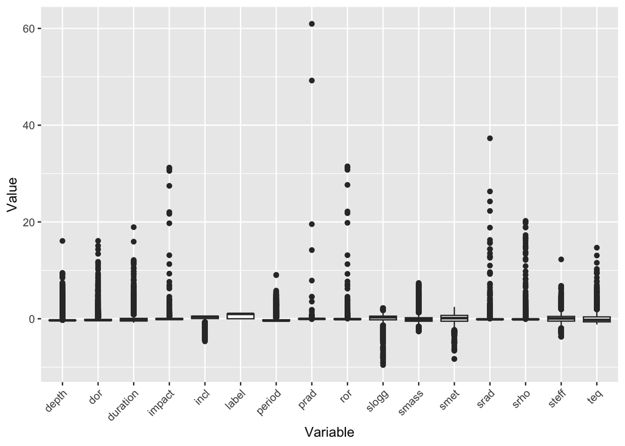

By plotting the boxplot with the standardized columns, we can observe that there are a couple standout outliers that are far apart from the majority. However, by observing the plot, it is obvious that if we remove outliers by the Interquartile Range (IQR) method, we will be removing a very large amount of data, which is not a good choice. Thus, I will try to remove the outliers by z-score as an alternative method since we have a big dataset and this method take into account the central tendency and dispersion of the entire dataset. Also, as the significant abnormal observations occur in the impact, ror, prad, and srad columns, which are across three of the four different predictor variable groups, I decided to remove them as they do not show any natural variability:

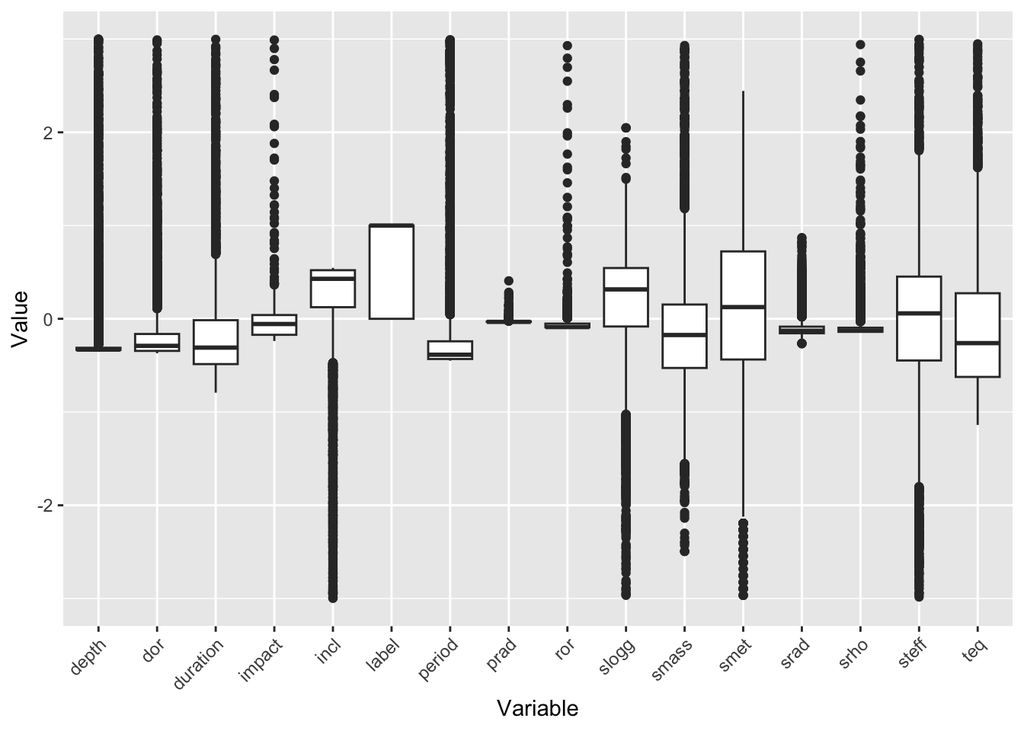

```
## [1] 5651   16
```

The plot above is the boxplots of the columns with outliers removed by z-score. It seems like we removed 1208 rows and have 5651 rows left, which the outliers are 17.6% of the data. Thus, I considered to keep those datapoints to avoid removing too much data.

## Splitting data

```r
#library(caret)

df2 <- df %>%
  mutate(label = case_when(
    label == "CONFIRMED" ~ 0,
    label == "FALSE POSITIVE" ~ 1
  ))

numeric_columns <- sapply(df2, is.numeric) & names(df2) != "label"
df2[numeric_columns] <- scale(df2[numeric_columns])

# Splitting the data into training and test sets
set.seed(777)
s <- sample(nrow(df2), round(0.7 * nrow(df2)))
train <- df2[s, ]
test <- df2[-s, ]

# Separating predictors and response
pred.train <- train[, !(names(train) %in% 'label')]
pred.test <- test[, !(names(test) %in% 'label')]
resp.train <- train$label
resp.test <- test$label
```

To prepare my dataset for ML analysis, I split it into training and testing sets with a 70-30% split. The dataset df was divided into train and test sets based on the label column, and then I separated the predictive variables and response variable for both sets, ensuring a consistent structure for model training and evaluation. I also set a seed value of 777 to make the process reproducible.

## Logistic Regression:

```r
log.out <- glm(label ~ ., data = train, family = "binomial")
# Predicting on the test set
predicted_prob <- predict(log.out, newdata = test, type = "response")

library(pROC)
# Calculate Metrics (ROC, AUC, Youden's J, Accuracy, MCR)
calculate_metrics <- function(test_data, predicted_prob) {
  roc_out <- roc(test_data$label, predicted_prob)
  auc_value <- auc(roc_out)
  youden_j <- roc_out$sensitivities + roc_out$specificities - 1
  optimal_index <- which.max(youden_j)
  optimal_threshold <- round(roc_out$thresholds[optimal_index],3)

  predicted_class <- ifelse(predicted_prob > optimal_threshold, 1, 0)
  confusion_matrix <- table(Predicted = predicted_class, Actual = test_data$label)

  accuracy <- sum(diag(confusion_matrix)) / sum(confusion_matrix)
  MCR <- mean(predicted_class != test_data$label)

  list(roc_out = roc_out, auc = auc_value, optimal_threshold = optimal_threshold,
       accuracy = accuracy, MCR = MCR, confusion_matrix = confusion_matrix)
}
metrics_log <- calculate_metrics(test, predicted_prob)
```

```r
# Print Metrics and Plot ROC Curve
print(paste("Logistic AUC:", metrics_log$auc))
```

```
## [1] "Logistic AUC: 0.947436455654438"
```

```r
print(paste("Logistic optimal_threshold:", metrics_log$optimal_threshold))
```

```
## [1] "Logistic optimal_threshold: 0.677"
```

```r
print(paste("Logistic Accuracy:", metrics_log$accuracy))
```

```
## [1] "Logistic Accuracy: 0.882410106899903"
```

```r
print(paste("Logistic MCR:", metrics_log$MCR))
```

```
## [1] "Logistic MCR: 0.117589893100097"
```

```r
print(metrics_log$confusion_matrix)
```

```
##          Actual
## Predicted    0    1
##         0  655  186
##         1   56 1161
```

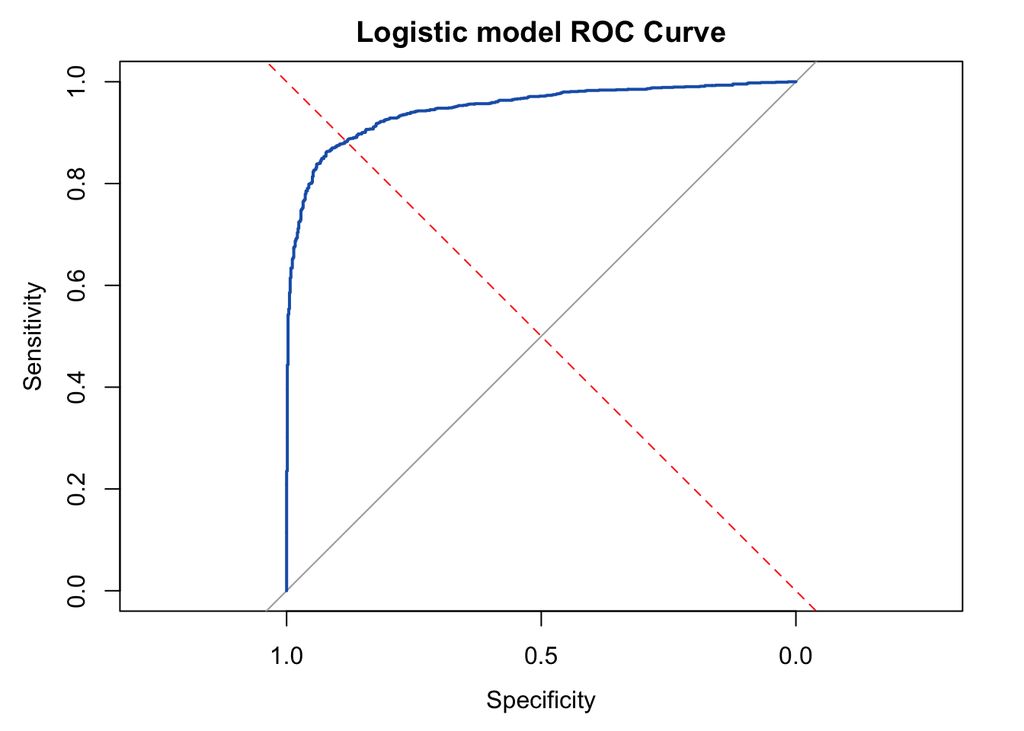

```r
# Plotting ROC Curve
plot(metrics_log$roc_out, main = "Logistic model ROC Curve", col = "#1c61b6")
abline(a = 0, b = 1, col = "red", lty = 2)
```

The logistic model does perform well on the data as the accuracy is high and the misclassification rate is low with the optimal threshold. Also, the high value in AUC indicates that this model is good at separating the CONFIRMED group and the FALSE POSITIVE group.

## Random Forest

```
## [1] "RandomForest AUC: 0.973586142879371"
```

```
## [1] "RandomForest optimal_threshold: 0.715"
```

```
## [1] "RandomForest Accuracy: 0.91156462585034"
```

```
## [1] "RandomForest MCR: 0.0884353741496599"
```

```
##          Actual
## Predicted    0    1
##         0  684  155
##         1   27 1192
```

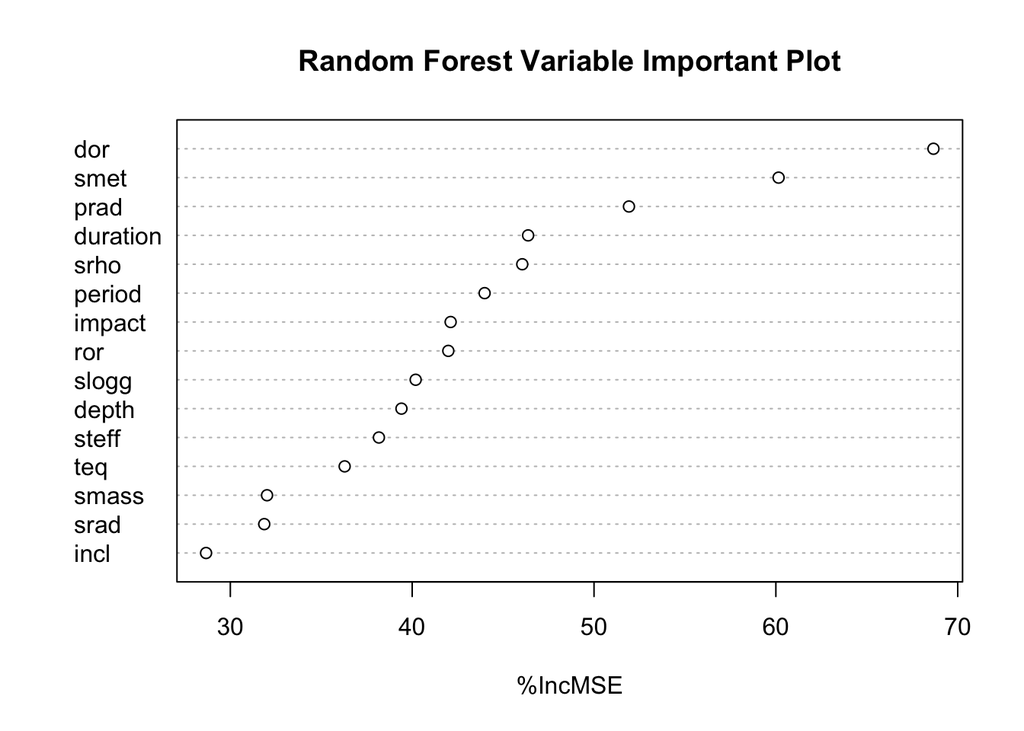

## Gradient Boosting (xgboost)

```
## The optimal number of trees is  23
```

```
## [1] "Gradient Boosting AUC: 0.973507831645464"
```

```
## [1] "Gradient Boosting optimal_threshold: 0.72"
```

```
## [1] "Gradient Boosting Accuracy: 0.912536443148688"
```

```
## [1] "Gradient Boosting MCR: 0.087463556851312"
```

```
##          Actual
## Predicted    0    1
##         0  668  137
##         1   43 1210
```

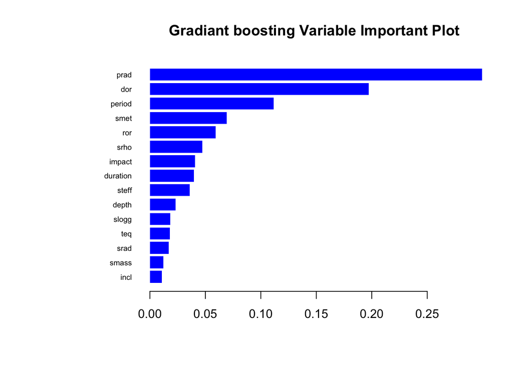

From the Gradiant Boosting Variable important plot, we can see that prad, dor, and period columns are more important than the others.Combine with the observation above, dor is confirmed to be a very important variable.

## K-nearest neighbour

```
## The optimal number of nearest neighbors is  13
```

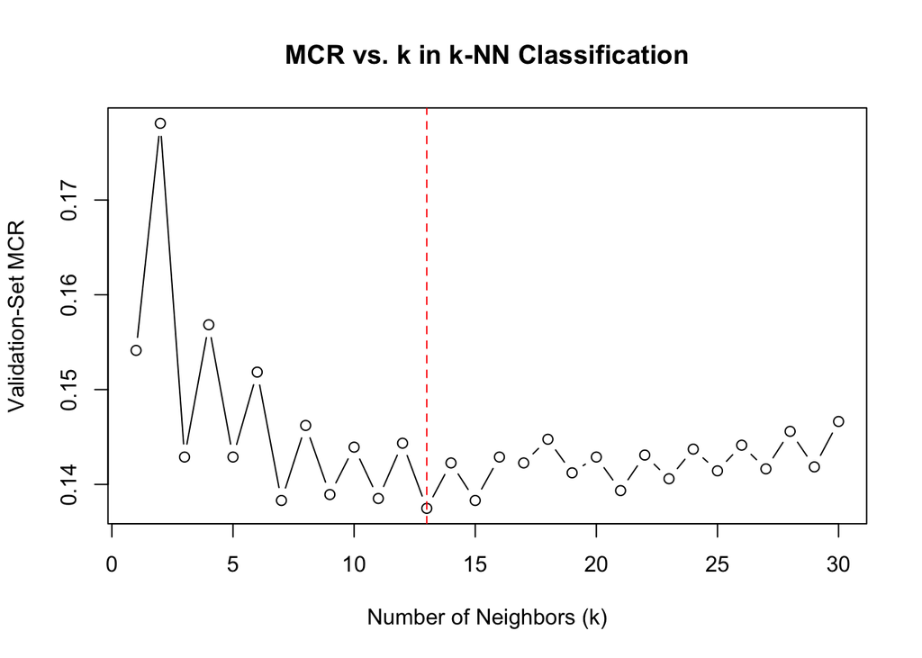

```
## [1] "KNN AUC: 0.663070092730942"
```

```
## [1] "KNN Accuracy: 0.878522837706511"
```

```
## [1] "KNN MCR: 0.121477162293489"
```

```
##          Actual
## Predicted    0    1
##         0  611  150
##         1  100 1197
```

## Model Comparison

```r
model_comparison <- data.frame(
  Model = c("Logistic", "RandomForest", "Gradient Boosting", "KNN"),
  AUC = c(metrics_log$auc, metrics_rf$auc, metrics_xgb$auc, KNN_auc),
  MCR = c(metrics_log$MCR, metrics_rf$MCR, metrics_xgb$MCR, KNN_mcr)
)

print(model_comparison)
```

```
##               Model       AUC        MCR
## 1          Logistic 0.9474365 0.11758989
## 2      RandomForest 0.9735861 0.08843537
## 3 Gradient Boosting 0.9735078 0.08746356
## 4               KNN 0.6630701 0.12147716
```

## ROC curves comparison between models

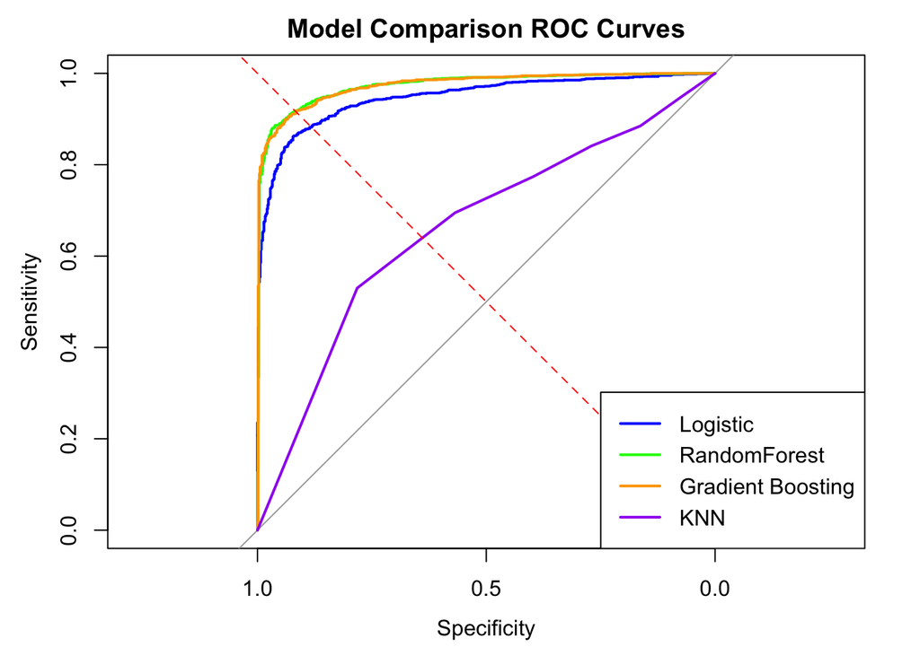

```r
library(pROC)

# Plot the first ROC curve (e.g., Logistic)
plot(metrics_log$roc_out, main = "Model Comparison ROC Curves", col = "blue", lwd = 2)

# Add the ROC curve for RandomForest
lines(metrics_rf$roc_out, col = "green", lwd = 2)

# Add the ROC curve for Gradient Boosting
lines(metrics_xgb$roc_out, col = "orange", lwd = 2)

# Add the ROC curve for KNN (assuming KNN_roc_out is defined)
lines(KNN_roc_out, col = "purple", lwd = 2)

# Add a diagonal line for reference
abline(a = 0, b = 1, col = "red", lty = 2)

# Add a legend
legend("bottomright", legend = c("Logistic", "RandomForest", "Gradient Boosting", "KNN"),
       col = c("blue", "green", "orange", "purple"), lwd = 2)
```

```r
print(paste("RandomForest optimal_threshold:", metrics_rf$optimal_threshold))
```

```
## [1] "RandomForest optimal_threshold: 0.715"
```

```r
metrics_rf$confusion_matrix
```

```
##          Actual
## Predicted    0    1
##         0  684  155
##         1   27 1192
```